# QBUS2820 - Predictive Analytics

# Tutorial 9 - Dimensionality Reduction Methods

## What is Dimensionality Reduction?

- Dimension Reduction reduces the number of input variables/features
- If we have $p$ input features we can reduce it down to a smaller number $M$ where $M << p$
- For example we might have 100 ($p$) features about a customer which we might reduce to 10 ($M$) features

## Principal Component Analysis

There are many algorithms for dimension reduction. One popular choice is Principal Component Analysis (PCA).

PCA works by creating new features which are combinations of the original features. The new features (called components) are ranked in order of the variance which they explain from most variance to least. In other words the first principal component is the first new feature. The first feature then contains the most information possible about the data.

An additional constraint is imposed: each principal component must be orthogonal to the others. Another way to think of PCA is that it transforms the original feature space to a new smaller feature space, which different axes.

### Visualisation of PCA process

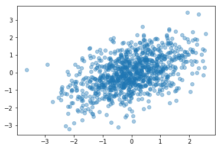

```python
from scipy.stats import multivariate_normal
import numpy as np
import matplotlib.pyplot as plt

# Generate some data with two features (2D)

means = [0, 0]
cov = np.matrix([ [1, 0.5], [0.5, 1] ])

X = multivariate_normal.rvs(mean = means, cov = cov, size = 1000)

plt.scatter(X[:,0], X[:,1], alpha = 0.4)

plt.show()
```

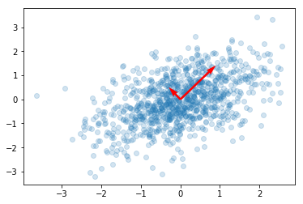

```python
# Learn the first two Principal Components of the data
# Plot the components
# PCA is a projection of the data to these two new axes
# Read: http://scikit-learn.org/stable/modules/generated/sklearn.decomposition.PCA.html

from sklearn.decomposition import PCA

pca = PCA(n_components = 2)

pca.fit(X)

# Note the shape of attribute "components": shape (n_components, n_features)
W = pca.components_

plt.scatter(X[:,0], X[:,1], alpha = 0.2)

# Read: https://matplotlib.org/api/_as_gen/matplotlib.axes.Axes.quiver.html
# A smaller "scale" parameter makes the arrow longer,
# so the length of arrow is proportional to variance explained by different components
plt.quiver(np.zeros(2), np.zeros(2), W[:,0], W[:,1], scale_units='xy', scale=1/pca.explained_variance_, color = "red")

plt.show()
```

```python
W
```

```
array([[ 0.72131023,  0.69261212],
       [-0.69261212,  0.72131023]])
```

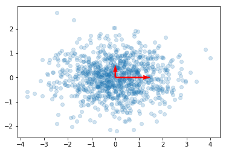

```python
# Rotate the coordinates to align with cartesian coordinates
# Notice that the first component is along the horizontal axis
# It's length is proportional to variance
# Most of the data varies along the new horizontal axis

T = pca.transform(X)

plt.scatter(T[:,0], T[:,1], alpha = 0.2)

ax = np.array([[1, 0], [0, 1]])

plt.quiver(np.zeros(2), np.zeros(2), ax[:,0], ax[:,1], scale_units='xy', scale=1/pca.explained_variance_, color = "red")

plt.show()
```

### Projection to lower dimensions

After calculating the principal components the next stage is to project the data to the lower dimension version given by the principal components.

Suppose we want to project our data to the first principal component. We convert the data from 2D to 1D. See below for an illustration

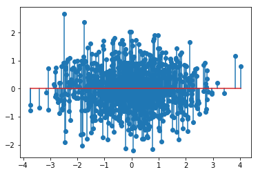

```python
# T is the transformed version with two principal components
# We want to project the data onto the red line

plt.stem(T[:,0], T[:,1], alpha = 0.1)

plt.show()
```

To do this we need to multiply the component weights with the data.

In this example it just means we project to the horizontal axis. Therefore we have converted 2D data to 1D data. This is dimension reduction!

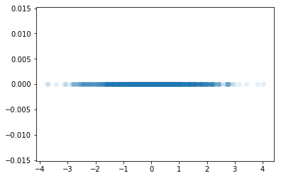

```python
# Reduce the dimension
# AKA project on to the principal components
pca = PCA(n_components=1)
pca.fit(X)
# Apply dimensionality reduction to X.
T_small = pca.transform(X)

# Alternatively do the following
# T_small = np.dot(X, pca.components_[:, 0])

plt.scatter(T_small, np.zeros(len(T_small)), alpha = 0.1)

plt.show()
```

Weights for the first principle component. Note the shape of attribute **components_ : array, shape (n_components, n_features)**

```python
weights_first= pca.components_[0,:]
weights_first
```

```
array([ 0.72131023,  0.69261212])
```

Note the weights are constrainted

```python
np.linalg.norm(weights_first)
```

```
1.0
```

## Interpretation of Weights (Loadings)

The values in the weights matrix describe a linear combination of the original variables.

For example the weights of the first principal component from the previous example are $[ 0.72131023, 0.69261212]$. This means that the first principal component $z_1 = 0.7213 x_1 + 0.6926 x_2$.

The magnitude of values in a principal component reflect how much the variable contributes to the component. The magnitude is relative not absolute.

#### Variables Lose Meaning

Your transformed variables are combinations of existing variables. Therefore you should not make claims about the relationship of the original variables.

## Practical Considerations

### Mean centering

You should always mean centre the data. This means calculate the mean of each feature and subtract this from your data.

### Variables must share the same scale

You should standardize or normalize the variables so that they have unit variance.

## Selecting number of components

There are numerous methods to select a suitable number of components including:

- Cross Validation (Try Tutorial 09 tasks)
- Scree plot (Explained variance)
- Elbow method

### Scree Plot

The Scree plot shows the proportion of total explained variance against the number of principal components. As the number of components approaches to $p$ the total explained varianced approaches 100%.

At some point we will be satisfied with the amount of explained variance. We might set this threshold at 95%, 90% or 85%. It depends on how much information you think you need to retain. We set the number of components to this corresponding proportion of explained variance.

```python
import pandas as pd

br_df = pd.read_excel("BatonRouge.xls")

br_df.head()
```

|  | Price | SQFT | Bedrooms | Baths | Age | Occupancy | Pool | Style | Fireplace | Waterfront | DOM |
| --- | --- | --- | --- | --- | --- | --- | --- | --- | --- | --- | --- |
| 0 | 66500 | 741 | 1 | 1 | 18 | 1 | 1 | 1 | 1 | 0 | 6 |
| 1 | 66000 | 741 | 1 | 1 | 18 | 2 | 1 | 1 | 0 | 0 | 23 |
| 2 | 68500 | 790 | 1 | 1 | 18 | 1 | 0 | 1 | 1 | 0 | 8 |
| 3 | 102000 | 2783 | 2 | 2 | 18 | 1 | 0 | 1 | 1 | 0 | 50 |
| 4 | 54000 | 1165 | 2 | 1 | 35 | 2 | 0 | 1 | 0 | 0 | 190 |

```python
X = br_df[br_df.columns.difference(['Price']) ]

# Standardisation. Very important!
X = (X - X.mean()) / X.std()

X.head()
```

|  | Age | Baths | Bedrooms | DOM | Fireplace | Occupancy | Pool | SQFT | Style | Waterfront |
| --- | --- | --- | --- | --- | --- | --- | --- | --- | --- | --- |
| 0 | -0.091547 | -1.589938 | -3.072082 | -0.717163 | 0.880680 | -0.949928 | 3.398152 | -1.572206 | -0.752982 | -0.278877 |
| 1 | -0.091547 | -1.589938 | -3.072082 | -0.538021 | -1.134435 | 0.731912 | 3.398152 | -1.572206 | -0.752982 | -0.278877 |
| 2 | -0.091547 | -1.589938 | -3.072082 | -0.696088 | 0.880680 | -0.949928 | -0.294005 | -1.523600 | -0.752982 | -0.278877 |
| 3 | -0.091547 | 0.043871 | -1.662631 | -0.253502 | 0.880680 | -0.949928 | -0.294005 | 0.453390 | -0.752982 | -0.278877 |
| 4 | 0.897156 | -1.589938 | -1.662631 | 1.221786 | -1.134435 | 0.731912 | -0.294005 | -1.151612 | -0.752982 | -0.278877 |

```python
# By default it will calculate all p components
# Adjust n_components to save some time!
# http://scikit-learn.org/stable/modules/generated/sklearn.decomposition.PCA.html
pca = PCA()

pca.fit(X)
```

```
PCA(copy=True, iterated_power='auto', n_components=None, random_state=None,
  svd_solver='auto', tol=0.0, whiten=False)
```

```python
# The explained variance of each variable in isolation
print(pca.explained_variance_ratio_)
```

```
[ 0.29741114  0.11971639  0.11072041  0.09905002  0.09352825  0.0831673
  0.07736634  0.0583377   0.03758198  0.02312049]
```

```python
# The variance is relative to the previous component so we calculate the cumulative version
# It's a value between 0-1 so we multiply by 100 to get a percentage
cum_var = np.cumsum(pca.explained_variance_ratio_) * 100

print(cum_var)
```

```
[  29.74111364   41.71275256   52.78479314   62.68979495   72.04261974
   80.3593494    88.09598304   93.92975285   97.68795124  100.        ]
```

In this case it seems that over 80% of the variance can be explained from the first 6 principal components.

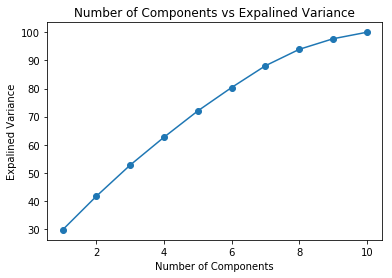

```python
plt.plot(np.arange(1, 11), cum_var, marker = "o")

plt.xlabel("Number of Components")
plt.ylabel("Expalined Variance")

plt.title("Number of Components vs Expalined Variance")

plt.show()
```

### Elbow Method

The Elbow method uses a Scree plot but does not define a fixed variance threshold. Instead it finds the "elbow" point in the scree plot. The elbow point is the point of maximum gradient. Beyond this point we don't expect much new information to be added. So we select this point as the required number of components.

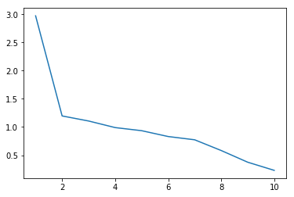

```python
difference = np.diff(pca.explained_variance_ratio_)

plt.plot(np.arange(1, 11), pca.explained_variance_)

plt.show()
```

```python
max_diff_idx = np.argmax(np.abs(difference))

max_diff_idx
```

```
0
```

In this case the elbow method selected the difference associated with index 0, which means we only need the first principal component! Obviously this is not a good choice as it only captures about 30% of the variance.

Further, we notice that there is another clear drop at the 7th principle component, thus we might consider the number of principle components as 7.

## Visualisation of Principal Component Weights

```python
first_component_weights = pd.DataFrame({'Weight': pca.components_[0,:], 'Feature': X.columns})

first_component_weights = first_component_weights.sort_values('Weight')

first_component_weights
```

|  | Feature | Weight |
| --- | --- | --- |
| 5 | Occupancy | -0.270345 |
| 0 | Age | -0.197941 |
| 3 | DOM | 0.082443 |
| 8 | Style | 0.129983 |
| 6 | Pool | 0.185678 |
| 9 | Waterfront | 0.196350 |
| 4 | Fireplace | 0.333930 |
| 2 | Bedrooms | 0.429627 |
| 1 | Baths | 0.490359 |
| 7 | SQFT | 0.504450 |

Still, the norm of the weights of the principle component is 1

```python
np.linalg.norm(pca.components_[0])
```

```
1.0
```

The largest contributors of information to the first component is SQFT. In plain words, SQFT gives us the most information.

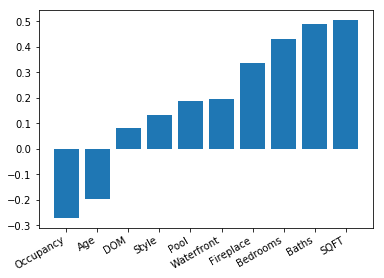

```python
test = first_component_weights
test = test.reset_index(drop = True)

first_component_weights = first_component_weights.reset_index(drop=True)

plt.bar(np.arange(len(first_component_weights)), first_component_weights['Weight'])

# Xtick position, label, rotation and alignment
plt.xticks(np.arange(len(first_component_weights)), first_component_weights['Feature'],
              rotation = 30, horizontalalignment = "right")

plt.show()
```